# Permutation and the Bootstrap test

## Exercise 3 - How Much Do Professors Earn?

For this exercise we will use the Salaries data from the carData package.

```r
head(carData::Salaries)
```

```
##        rank discipline yrs.since.phd yrs.service  sex salary
## 1      Prof          B            19          18 Male 139750
## 2      Prof          B            20          16 Male 173200
## 3  AsstProf          B             4           3 Male  79750
## 4      Prof          B            45          39 Male 115000
## 5      Prof          B            40          41 Male 141500
## 6 AssocProf          B             6           6 Male  97000
```

We’ll focus on the salary variable.

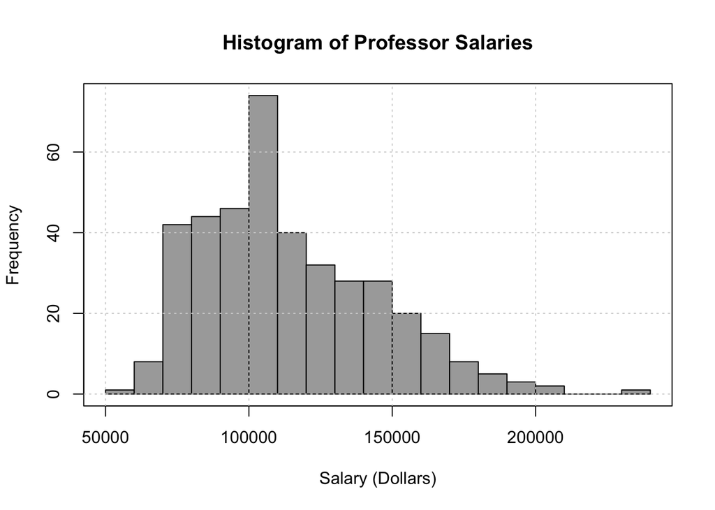

```r
prof_salary = carData::Salaries$salary
hist(prof_salary, col = "darkgrey", breaks = 20,
     xlab = "Salary (Dollars)", main = "Histogram of Professor Salaries")
box()
grid()
```

What is the 10th percentile, $\hat{p}_0.10$ of this data? That is, what is the salary that 10% of the professors make less than?

```r
quantile(prof_salary, probs = 0.10)
```

```
##     10%
## 77380.8
```

Create a 99% bootstrap confidence interval for $p_{0.10}$, the true 10th percentile of professor salaries. Use 5000 bootstrap samples. Also plot a histogram of the bootstrap replicates of $\hat{p}_{0.10}$.

```r
set.seed(1)
boot_10th = rep(0, 5000)
# perform bootstrap resampling here
# store the bootstrap replicates in boot_10th
# create histogram here
# calculate confidence interval here
```

## Exercise 4 - How Long Will You Survive Cancer?

For this exercise we will use the Melanoma data from the MASS package.

```r
head(MASS::Melanoma)
```

```
##   time status sex age year thickness ulcer
## 1   10      3   1  76 1972      6.76     1
## 2   30      3   1  56 1968      0.65     0
## 3   35      2   1  41 1977      1.34     0
## 4   99      3   0  71 1968      2.90     0
## 5  185      1   1  52 1965     12.08     1
## 6  204      1   1  28 1971      4.84     1
```

We’ll focus on the time variable which is survival time in days.

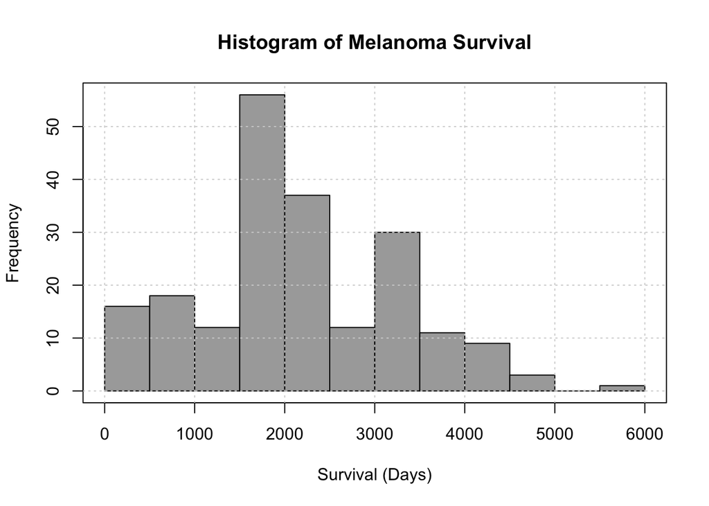

```r
mel_survive = MASS::Melanoma$time
hist(mel_survive, col = "darkgrey",
     xlab = "Survival (Days)", main = "Histogram of Melanoma Survival")
box()
grid()
```

What is the probability of surviving longer that 10 years? That is, if X is the survival time in years, what is $\mathbb{P}[X>10]$?

With this data, we could estimate. We calculate $\hat{P}[X>10]$ using

```r
mean(mel_survive > 10 * 365)
```

```
## [1] 0.1121951
```

Create a 95% bootstrap confidence interval for $\mathbb{P}[X>10]$, the probability of surviving longer that 10 years. Use 20,000 bootstrap samples. Also plot a histogram of the bootstrap replicates of $\hat{P}[X>10]$.

```r
set.seed(1)
boot_10_year_surv = rep(0, 20000)
# perform bootstrap resampling here
# store the bootstrap replicates in boot_10_year_surv
# create histogram here
# calculate confidence interval here
```

## Exercise 5 - Who’s Tweeting?

Returning to the tweet data, the David Robinson analysis attempted to show that there were two different groups tweeting on the @realDonaldTrump account. (This is a common occurrence for public figures. Some will be from a media team, while others are from the individual. Some choose to disclose when this occurs, others, like the Donald Trump account, do not.)

In this case the hypothesis was that the tweets sent from an iPhone were from campaign staff, while the tweets sent from Android were sent from Donald Trump.

```r
android_tweets = nchar(subset(tweets, source == "Android")$text)
iphone_tweets  = nchar(subset(tweets, source == "iPhone")$text)
```

The posted analysis uses many detailed analyses to argue for this difference, but we’ll resort to some simpler methods.

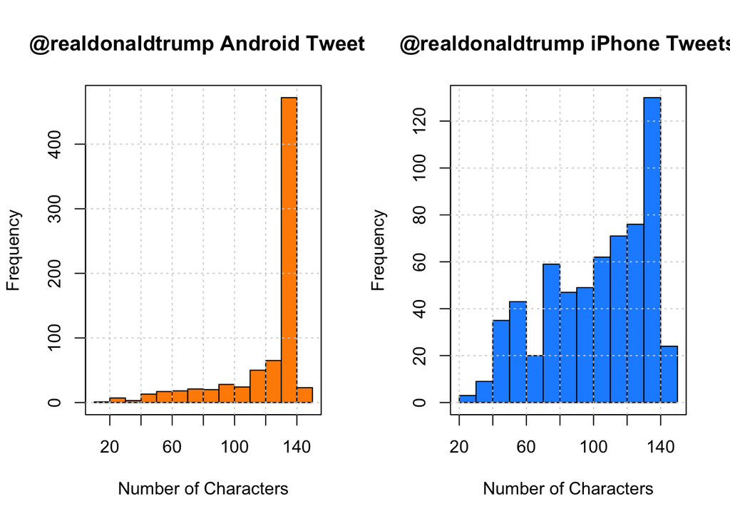

```r
par(mfrow = c(1, 2))
hist(android_tweets, col = "darkorange",
     main = "@realdonaldtrump Android Tweets",
     xlab = "Number of Characters")
box()
grid()
hist(iphone_tweets, col = "dodgerblue",
     main = "@realdonaldtrump iPhone Tweets",
     xlab = "Number of Characters")
box()
grid()
```

Looking at these two histograms, we see a clear difference in distributions. However, this could just be due to chance…

Further simplifying, let’s look at the sample standard deviations of these two datasets.

```r
sd(android_tweets)
```

```
## [1] 26.34046
```

```r
sd(iphone_tweets)
```

```
## [1] 30.8574
```

```r
sAndroid=26.34
siPhone=30.86
```

If they were sent by the same person, you’d expect them to be equal. (The distributions should be the same, so the standard deviations should be the same.) Or in reality, at least close, but different due to random chance.

Is this difference due to chance?

```r
set.seed(1)
boot_sd_ratio = rep(0, 5000)
# perform bootstrap resampling here
# store the bootstrap replicates in boot_sd_ratio
# create histogram here
# calculate confidence interval here
```